# **Working With Strings In Pandas**

In the previous mission, we learned how to use the apply(), map(), and applymap() methods to apply a function to a series. While we could certainly use these methods to clean strings in columns, pandas has built in many vectorized string methods that can perform these tasks quicker and with less keystrokes.

We introduced some of these methods already in the Pandas Fundamentals course when we learned the following data cleaning tasks:

Cleaning column names Extracting values from the start of strings Extracting values from the end of strings In this mission, we'll learn a couple other string cleaning tasks such as:

Finding specific strings or substrings in columns Extracting substrings from unstructured data Removing strings or substrings from a series As we learn these tasks, we'll also work to build intuition around how these string methods operate so that you can explore methods we haven't explicitly covered on your own.

Below are descriptions for the columns we'll be working with:

ShortName - Name of the country Region - The region the country belongs to IncomeGroup - The income group the country belongs to, based on Gross National Income (GNI) per capita CurrencyUnit - Name of country's currency SourceOfMostRecentIncomeAndExpenditureData - The name of the survey used to collect the income and expenditure data SpecialNotes - Contains any miscellaneous notes about the data

To start, let's read the data sets into pandas and combine them.

We've already read World_Happiness_2015.csv into a dataframe called happiness2015 and World_dev.csv into a dataframe called world_dev.

Use the pd.merge() function to combine happiness2015 and world_dev. Save the resulting dataframe to merged. As a reminder, you can use the following syntax to combine the dataframes: pd.merge(left=df1, right=df2, how='left', left_on='left_df_Column_Name', right_on='right_df_Column_Name'). Set the left_on parameter to the Country column from happiness2015 and the right_on parameter to the ShortName column from world_dev. Use the DataFrame.rename() method to rename the SourceOfMostRecentIncomeAndExpenditureData column in merged to IESurvey (because we don't want to keep typing that long name!). We've already saved the mapping to a dictionary named col_renaming. Make sure to set the axis parameter to 1.

```python
import pandas as pd

happiness2015 = pd.read_csv('World_Happiness_2015.csv')
world_dev = pd.read_csv("World_dev.csv")

happiness2015.head()
```

|  | Country | Region | Happiness Rank | Happiness Score | Standard Error | Economy (GDP per Capita) | Family | Health (Life Expectancy) | Freedom | Trust (Government Corruption) | Generosity | Dystopia Residual |
| --- | --- | --- | --- | --- | --- | --- | --- | --- | --- | --- | --- | --- |
| 0 | Switzerland | Western Europe | 1 | 7.587 | 0.03411 | 1.39651 | 1.34951 | 0.94143 | 0.66557 | 0.41978 | 0.29678 | 2.51738 |
| 1 | Iceland | Western Europe | 2 | 7.561 | 0.04884 | 1.30232 | 1.40223 | 0.94784 | 0.62877 | 0.14145 | 0.43630 | 2.70201 |
| 2 | Denmark | Western Europe | 3 | 7.527 | 0.03328 | 1.32548 | 1.36058 | 0.87464 | 0.64938 | 0.48357 | 0.34139 | 2.49204 |
| 3 | Norway | Western Europe | 4 | 7.522 | 0.03880 | 1.45900 | 1.33095 | 0.88521 | 0.66973 | 0.36503 | 0.34699 | 2.46531 |
| 4 | Canada | North America | 5 | 7.427 | 0.03553 | 1.32629 | 1.32261 | 0.90563 | 0.63297 | 0.32957 | 0.45811 | 2.45176 |

```python
world_dev.head()
```

|  | CountryCode | ShortName | TableName | LongName | Alpha2Code | CurrencyUnit | SpecialNotes | Region | IncomeGroup | Wb2Code | ... | GovernmentAccountingConcept | ImfDataDisseminationStandard | LatestPopulationCensus | LatestHouseholdSurvey | SourceOfMostRecentIncomeAndExpenditureData | VitalRegistrationComplete | LatestAgriculturalCensus | LatestIndustrialData | LatestTradeData | LatestWaterWithdrawalData |
| --- | --- | --- | --- | --- | --- | --- | --- | --- | --- | --- | --- | --- | --- | --- | --- | --- | --- | --- | --- | --- | --- |
| 0 | AFG | Afghanistan | Afghanistan | Islamic State of Afghanistan | AF | Afghan afghani | Fiscal year end: March 20; reporting period fo... | South Asia | Low income | AF | ... | Consolidated central government | General Data Dissemination System (GDDS) | 1979 | Multiple Indicator Cluster Survey (MICS), 2010/11 | Integrated household survey (IHS), 2008 | NaN | 2013/14 | NaN | 2013.0 | 2000.0 |
| 1 | ALB | Albania | Albania | Republic of Albania | AL | Albanian lek | NaN | Europe & Central Asia | Upper middle income | AL | ... | Budgetary central government | General Data Dissemination System (GDDS) | 2011 | Demographic and Health Survey (DHS), 2008/09 | Living Standards Measurement Study Survey (LSM... | Yes | 2012 | 2011.0 | 2013.0 | 2006.0 |
| 2 | DZA | Algeria | Algeria | People's Democratic Republic of Algeria | DZ | Algerian dinar | NaN | Middle East & North Africa | Upper middle income | DZ | ... | Budgetary central government | General Data Dissemination System (GDDS) | 2008 | Multiple Indicator Cluster Survey (MICS), 2012 | Integrated household survey (IHS), 1995 | NaN | NaN | 2010.0 | 2013.0 | 2001.0 |
| 3 | ASM | American Samoa | American Samoa | American Samoa | AS | U.S. dollar | NaN | East Asia & Pacific | Upper middle income | AS | ... | NaN | NaN | 2010 | NaN | NaN | Yes | 2007 | NaN | NaN | NaN |
| 4 | ADO | Andorra | Andorra | Principality of Andorra | AD | Euro | NaN | Europe & Central Asia | High income: nonOECD | AD | ... | NaN | NaN | 2011. Population data compiled from administra... | NaN | NaN | Yes | NaN | NaN | 2006.0 | NaN |

5 rows × 31 columns

```python
col_renaming = {'SourceOfMostRecentIncomeAndExpenditureData': 'IESurvey'}

merged = pd.merge(left = happiness2015, right = world_dev, how = 'left', left_on = 'Country', right_on = 'ShortName')
merged = merged.rename(col_renaming, axis = 1) # To rename a column, use the following syntax: df = df.rename(mapping_dict, axis=1).

merged.head()
```

|  | Country | Region_x | Happiness Rank | Happiness Score | Standard Error | Economy (GDP per Capita) | Family | Health (Life Expectancy) | Freedom | Trust (Government Corruption) | ... | GovernmentAccountingConcept | ImfDataDisseminationStandard | LatestPopulationCensus | LatestHouseholdSurvey | IESurvey | VitalRegistrationComplete | LatestAgriculturalCensus | LatestIndustrialData | LatestTradeData | LatestWaterWithdrawalData |
| --- | --- | --- | --- | --- | --- | --- | --- | --- | --- | --- | --- | --- | --- | --- | --- | --- | --- | --- | --- | --- | --- |
| 0 | Switzerland | Western Europe | 1 | 7.587 | 0.03411 | 1.39651 | 1.34951 | 0.94143 | 0.66557 | 0.41978 | ... | Consolidated central government | Special Data Dissemination Standard (SDDS) | 2010 | NaN | Expenditure survey/budget survey (ES/BS), 2004 | Yes | 2008 | 2010.0 | 2013.0 | 2000.0 |
| 1 | Iceland | Western Europe | 2 | 7.561 | 0.04884 | 1.30232 | 1.40223 | 0.94784 | 0.62877 | 0.14145 | ... | Consolidated central government | Special Data Dissemination Standard (SDDS) | 2011 | NaN | Integrated household survey (IHS), 2010 | Yes | 2010 | 2005.0 | 2013.0 | 2005.0 |
| 2 | Denmark | Western Europe | 3 | 7.527 | 0.03328 | 1.32548 | 1.36058 | 0.87464 | 0.64938 | 0.48357 | ... | Consolidated central government | Special Data Dissemination Standard (SDDS) | 2011 | NaN | Income tax registers (ITR), 2010 | Yes | 2010 | 2010.0 | 2013.0 | 2009.0 |
| 3 | Norway | Western Europe | 4 | 7.522 | 0.03880 | 1.45900 | 1.33095 | 0.88521 | 0.66973 | 0.36503 | ... | Consolidated central government | Special Data Dissemination Standard (SDDS) | 2011 | NaN | Income survey (IS), 2010 | Yes | 2010 | 2010.0 | 2013.0 | 2006.0 |
| 4 | Canada | North America | 5 | 7.427 | 0.03553 | 1.32629 | 1.32261 | 0.90563 | 0.63297 | 0.32957 | ... | Consolidated central government | Special Data Dissemination Standard (SDDS) | 2011 | NaN | Labor force survey (LFS), 2010 | Yes | 2011 | 2011.0 | 2013.0 | 1986.0 |

5 rows × 43 columns

## **2. Using Apply to Transform Strings**

In the last step, we combined happiness2015 and world_dev and assigned the result to merged. Below are the first five rows of merged (after removing some of the columns we don't need):

```python
merged.head()
```

|  | Country | Region_x | Happiness Rank | Happiness Score | Standard Error | Economy (GDP per Capita) | Family | Health (Life Expectancy) | Freedom | Trust (Government Corruption) | ... | GovernmentAccountingConcept | ImfDataDisseminationStandard | LatestPopulationCensus | LatestHouseholdSurvey | IESurvey | VitalRegistrationComplete | LatestAgriculturalCensus | LatestIndustrialData | LatestTradeData | LatestWaterWithdrawalData |
| --- | --- | --- | --- | --- | --- | --- | --- | --- | --- | --- | --- | --- | --- | --- | --- | --- | --- | --- | --- | --- | --- |
| 0 | Switzerland | Western Europe | 1 | 7.587 | 0.03411 | 1.39651 | 1.34951 | 0.94143 | 0.66557 | 0.41978 | ... | Consolidated central government | Special Data Dissemination Standard (SDDS) | 2010 | NaN | Expenditure survey/budget survey (ES/BS), 2004 | Yes | 2008 | 2010.0 | 2013.0 | 2000.0 |
| 1 | Iceland | Western Europe | 2 | 7.561 | 0.04884 | 1.30232 | 1.40223 | 0.94784 | 0.62877 | 0.14145 | ... | Consolidated central government | Special Data Dissemination Standard (SDDS) | 2011 | NaN | Integrated household survey (IHS), 2010 | Yes | 2010 | 2005.0 | 2013.0 | 2005.0 |
| 2 | Denmark | Western Europe | 3 | 7.527 | 0.03328 | 1.32548 | 1.36058 | 0.87464 | 0.64938 | 0.48357 | ... | Consolidated central government | Special Data Dissemination Standard (SDDS) | 2011 | NaN | Income tax registers (ITR), 2010 | Yes | 2010 | 2010.0 | 2013.0 | 2009.0 |
| 3 | Norway | Western Europe | 4 | 7.522 | 0.03880 | 1.45900 | 1.33095 | 0.88521 | 0.66973 | 0.36503 | ... | Consolidated central government | Special Data Dissemination Standard (SDDS) | 2011 | NaN | Income survey (IS), 2010 | Yes | 2010 | 2010.0 | 2013.0 | 2006.0 |
| 4 | Canada | North America | 5 | 7.427 | 0.03553 | 1.32629 | 1.32261 | 0.90563 | 0.63297 | 0.32957 | ... | Consolidated central government | Special Data Dissemination Standard (SDDS) | 2011 | NaN | Labor force survey (LFS), 2010 | Yes | 2011 | 2011.0 | 2013.0 | 1986.0 |

5 rows × 43 columns

Let's work with the **CurrencyUnit column** first. Suppose we wanted to extract the unit of currency without the leading nationality. For example, instead of "Danish krone" or "Norwegian krone", we just needed "krone".

If we wanted to complete this task for just one of the strings, we could use Python's string.split() method:

```python
words = 'Danish krone'

#Use the string.split() method to return the following list: ['Danish', 'krone']
listwords = words.split()

#Use the index -1 to return the last word of the list.
listwords[-1]
```

```
'krone'
```

Now, to repeat this task for each element in the Series, let's return to a concept we learned in the previous mission - the **Series.apply() method.**

Write a function called extract_last_word with the following criteria: The function should accept one parameter called element. Use the string.split() method to split the object into a list. First convert element to a string as follows: str(element). Return the last word of the list. Use the Series.apply() method to apply the function to the CurrencyUnit column. Save the result to merged['Currency Apply']. Use the Series.head() method to print the first five rows in merged['Currency Apply'].

```python
def extract_last_word(element):
    return str(element).split()[-1]

merged['Currency Apply'] = merged['CurrencyUnit'].apply(extract_last_word)
merged['Currency Apply'].head()
```

```
0     franc
1     krona
2     krone
3     krone
4    dollar
Name: Currency Apply, dtype: object
```

In the last exercise, we extracted the last word of each element in the CurrencyUnit column using the Series.apply() method. However, we also learned in the last mission that we should use built-in vectorized methods (if they exist) instead of the Series.apply() method for performance reasons.

Instead, we could've **split each element in the CurrencyUnit column into a list of strings with the Series.str.split() method,** the **vectorized equivalent of Python's string.split() method:**

In fact, pandas has built in a number of vectorized methods that perform the same operations for strings in series as Python string methods.

Below are some common vectorized string methods, but you can find the full list here:

Method Description Series.str.split() Splits each element in the Series. Series.str.strip() Strips whitespace from each string in the Series. Series.str.lower() Converts strings in the Series to lowercase. Series.str.upper() Converts strings in the Series to uppercase. Series.str.get() Retrieves the ith element of each element in the Series. Series.str.replace() Replaces a regex or string in the Series with another string. Series.str.cat() Concatenates strings in a Series. Series.str.extract() Extracts substrings from the Series matching a regex pattern.

We access these **vectorized string methods by adding a str between the Series name and method name:**

Series.str.method_name()

The **str attribute indicates that each object in the Series should be treated as a string,** without us having to explicitly change the type to a string like we did when using the apply method.

Note that we can also slice each element in the Series to extract characters, but we'd still need to use the str attribute. For example, below we access the first five characters in each element of the CurrencyUnit column:

```python
merged['CurrencyUnit'].str[0:5].head()
```

```
0    Swiss
1    Icela
2    Danis
3    Norwe
4    Canad
Name: CurrencyUnit, dtype: object
```

It's also good to know that vectorized string methods can be chained. For example, suppose we needed to **split** each element in the CurrencyUnit column into a list of strings using the Series.str.split() method **and capitalize** the letters using the Series.str.upper() method. You can use the following syntax to apply more than one method at once:

```python
merged['CurrencyUnit'].str.upper().str.split()
```

```
0                   [SWISS, FRANC]
1                 [ICELAND, KRONA]
2                  [DANISH, KRONE]
3               [NORWEGIAN, KRONE]
4               [CANADIAN, DOLLAR]
                  ...
153               [RWANDAN, FRANC]
154    [WEST, AFRICAN, CFA, FRANC]
155                            NaN
156               [BURUNDI, FRANC]
157    [WEST, AFRICAN, CFA, FRANC]
Name: CurrencyUnit, Length: 158, dtype: object
```

However, **don't forget to include str before each method name,** or you'll get an error!

Let's practice using vectorized string methods next.

Use the Series.str.split() method to split the CurrencyUnit column into a list of words and then use the Series.str.get() method to select just the last word. Assign the result to merged['Currency Vectorized']. Use the Series.head() method to print the first five rows in merged['Currency Vectorized'].

```python
merged['Currency Vectorized'] = merged['CurrencyUnit'].str.split().str.get(-1) # -1 indicates select last word

merged['Currency Vectorized'].head()
```

```
0     franc
1     krona
2     krone
3     krone
4    dollar
Name: Currency Vectorized, dtype: object
```

## **4. Exploring Missing Values with Vectorized String Methods**

We learned that using vectorized string methods results in:

Better performance Code that is easier to read and write Let's explore another benefit of using vectorized string methods next. Suppose we wanted to compute the length of each string in the CurrencyUnit column. If we use the Series.apply() method, what happens to the missing values in the column?

First, let's use the Series.isnull() method to confirm if there are any missing values in the column:

```python
merged['CurrencyUnit'] #presence of some null values
```

```
0                 Swiss franc
1               Iceland krona
2                Danish krone
3             Norwegian krone
4             Canadian dollar
                ...
153             Rwandan franc
154    West African CFA franc
155                       NaN
156             Burundi franc
157    West African CFA franc
Name: CurrencyUnit, Length: 158, dtype: object
```

```python
merged['CurrencyUnit'].isnull().sum()
```

```
13
```

So, we know that the CurrencyUnit column has 13 missing values.

Next, let's create a function to return the length of each currency unit and apply it to the CurrencyUnit column:

```python
def compute_lengths(element):
    return len(str(element))
lengths_apply = merged['CurrencyUnit'].apply(compute_lengths)
lengths_apply.head() #number of characters in the word string (including spaces)
```

```
0    11
1    13
2    12
3    15
4    15
Name: CurrencyUnit, dtype: int64
```

Then, we can **check the number of missing values in the result by setting the dropna parameter in the Series.value_counts() method to False:**

```python
lengths_apply.value_counts(dropna=False)

#13 rows have NaN
```

```
14    21
4     20
12    17
13    14
3     13
15    13
16    12
18     9
17     9
11     8
22     7
25     5
19     3
9      2
26     1
20     1
23     1
10     1
39     1
Name: CurrencyUnit, dtype: int64
```

Since the original column had **13 missing values and NaN doesn't appear** in the list of unique values above, we know our function must have treated **NaN as a string and returned a length of 3 for each NaN value.** This doesn't make sense - missing values shouldn't be treated as strings. They should instead have been excluded from the calculation.

If we wanted to exclude missing values, we'd have to update our function to something like this:

```python
def compute_lengths(element):
    if pd.isnull(element):
        pass
    else:
        return len(str(element))
lengths_apply = merged['CurrencyUnit'].apply(compute_lengths)
```

Let's confirm the behavior of pandas' vectorized string methods next.

Use the Series.str.len() method to return the length of each element in the CurrencyUnit column. Assign the result to lengths. Use the Series.value_counts() method to return the count of unique values in lengths. Set the dropna parameter to False so NaNs are counted, too. Assign the result to value_counts. If value_counts contains NaNs, it means the Series.str.len() method excluded them and didn't treat them as strings.

```python
lengths = merged['CurrencyUnit'].str.len()
value_counts = lengths.value_counts(dropna = False)

print(value_counts)
```

```
14.0    21
4.0     20
12.0    17
13.0    14
NaN     13
15.0    13
16.0    12
18.0     9
17.0     9
11.0     8
22.0     7
25.0     5
19.0     3
9.0      2
10.0     1
39.0     1
26.0     1
23.0     1
20.0     1
Name: CurrencyUnit, dtype: int64
```

## **5. Finding Specific Words in Strings**

In the last exercise, we identified a third benefit of using vectorized string methods - they exclude missing values:

Better performance Code that is easier to read and write Automatically excludes missing values Now that we know the benefits of using vectorized string methods, let's practice using them for specific data cleaning tasks.

Suppose we needed to parse the elements of a Series to find a string or substring that doesn't appear in the same position in each string. For example, let's look at the SpecialNotes column. A number of rows mention "national accounts", but the words appear in different places in each comment:

April 2013 database update: Based on IMF data, national accounts data were revised for 2000 onward; the **base year** changed to 2002. Based on IMF data, national accounts data have been revised for 2005 onward; the new base year is 2005.

If we wanted to determine how many comments contain this phrase, could we split them into lists? Since the formats are different, how could we tell which element contains the "national accounts" phrase?

We can handle problems like this with regular expressions, or regex for short. A regular expression is a sequence of characters that describes a search pattern, used to match characters in a string:

In pandas, regular expression is integrated with vectorized string methods to make finding and extracting patterns of characters easier. However, the rules for creating regular expressions can be quite complex, so don't worry about memorizing them. In this mission, we'll provide guidance on how to create the regex we need to use for the exercises, but you can also follow along using this documentation.

We've already saved the regex to a variable called pattern. The brackets, [], indicate that either "national accounts" or "National accounts" should produce a match.

Use the Series.str.contains() method to search for pattern in the SpecialNotes column. Assign the result to national_accounts. Use the Series.head() method to print the first five rows in national_accounts.

```python
pattern = r"[Nn]ational accounts"

national_accounts = merged['SpecialNotes'].str.contains(pattern)
national_accounts.head()
```

```
0     NaN
1     NaN
2     NaN
3     NaN
4    True
Name: SpecialNotes, dtype: object
```

## **6. Finding Specific Words in Strings Continued**

In the last screen, we used the Series.str.contains() method to see if a specific phrase appeared in a series. The result was a series containing True, False, and missing values:

```python
national_accounts = merged['SpecialNotes'].str.contains(r"[Nn]ational accounts")
#Return the value counts for each unique value in the Series, including missing values.
national_accounts.value_counts(dropna=False)
```

[output not shown]

Now, we should be able to use boolean indexing to return only the rows that contain "national accounts" or "National accounts" in the SpecialNotes column:

```python
merged[national_accounts]
```

[output not shown]

It looks like we got an error now because of the NaN values! One way we could fix this is to change the NaN values to False in national_accounts.

Let's practice a way we can easily make this change.

Use the Series.str.contains() method to search for pattern in the SpecialNotes column again. This time, also pass in the na parameter and set it to False. Assign the result to national_accounts. Use national_accounts to index merged, so that only rows that contain "national accounts" or "National accounts" in the SpecialNotes column are returned. Assign the result to merged_national_accounts. Use the DataFrame.head() method to print the first five rows in merged_national_accounts.

```python
pattern = r"[Nn]ational accounts"

national_accounts = merged['SpecialNotes'].str.contains(pattern, na=False)
merged_national_accounts = merged[national_accounts]
merged_national_accounts.head()
```

|  | Country | Region_x | Happiness Rank | Happiness Score | Standard Error | Economy (GDP per Capita) | Family | Health (Life Expectancy) | Freedom | Trust (Government Corruption) | ... | LatestPopulationCensus | LatestHouseholdSurvey | IESurvey | VitalRegistrationComplete | LatestAgriculturalCensus | LatestIndustrialData | LatestTradeData | LatestWaterWithdrawalData | Currency Apply | Currency Vectorized |
| --- | --- | --- | --- | --- | --- | --- | --- | --- | --- | --- | --- | --- | --- | --- | --- | --- | --- | --- | --- | --- | --- |
| 4 | Canada | North America | 5 | 7.427 | 0.03553 | 1.32629 | 1.32261 | 0.90563 | 0.63297 | 0.32957 | ... | 2011 | NaN | Labor force survey (LFS), 2010 | Yes | 2011 | 2011.0 | 2013.0 | 1986.0 | dollar | dollar |
| 7 | Sweden | Western Europe | 8 | 7.364 | 0.03157 | 1.33171 | 1.28907 | 0.91087 | 0.65980 | 0.43844 | ... | 2011 | NaN | Income survey (IS), 2005 | Yes | 2010 | 2010.0 | 2013.0 | 2007.0 | krona | krona |
| 8 | New Zealand | Australia and New Zealand | 9 | 7.286 | 0.03371 | 1.25018 | 1.31967 | 0.90837 | 0.63938 | 0.42922 | ... | 2013 | NaN | NaN | Yes | 2012 | 2010.0 | 2013.0 | 2002.0 | dollar | dollar |
| 9 | Australia | Australia and New Zealand | 10 | 7.284 | 0.04083 | 1.33358 | 1.30923 | 0.93156 | 0.65124 | 0.35637 | ... | 2011 | NaN | Expenditure survey/budget survey (ES/BS), 2003 | Yes | 2011 | 2011.0 | 2013.0 | 2000.0 | dollar | dollar |
| 14 | United States | North America | 15 | 7.119 | 0.03839 | 1.39451 | 1.24711 | 0.86179 | 0.54604 | 0.15890 | ... | 2010 | NaN | Labor force survey (LFS), 2010 | Yes | 2012 | 2008.0 | 2013.0 | 2005.0 | dollar | dollar |

5 rows × 45 columns

## **7. Extracting Substrings from a Series**

In the last screen, we learned how to use regular expressions and the Series.str.contains() method to search for patterns of characters in a column and index the dataframe based on the matches. Let's continue exploring the versatility of regular expressions while learning a new task - extracting characters from strings.

Suppose we wanted to extract any year mentioned in the SpecialNotes column. Notice that the characters in a year follow a specific pattern:

The first digit can be either 1 or 2, while the last three digits can be any number between 0 and 9.

With regular expressions, we use the following syntax to indicate a character could be a range of numbers:

```python
pattern = r"[0-9]"
```

And we use the following syntax to indicate a character could be a range of letters:

```python
#lowercase letters
pattern1 = r"[a-z]"
#uppercase letters
pattern2 = r"[A-Z]"
```

We could also make these ranges more restrictive. For example, if we wanted to find a three character substring in a column that starts with a number between 1 and 6 and ends with two letters of any kind, we could use the following syntax:

```python
pattern = r"[1-6][a-z][a-z]"
```

If we have a pattern that repeats, we can also use curly brackets { and } to indicate the number of times it repeats:m

```python
pattern = r"[1-6][a-z][a-z]" = r"[1-6][a-z]{2}"
```

Let's use what we've learned to explore the Series.str.extract() method.

Create a regular expression that will match years and assign it to the variable pattern. Note: we've already set up the pattern variable. Insert your answer inside the parantheses: "(your_answer)". Use pattern and the Series.str.extract() method to extract years from the SpecialNotes column. Assign the resulting Series to years.

```python
pattern =r"([1-2][0-9]{3})"

years = merged['SpecialNotes'].str.extract(pattern)

print(years)
```

```
        0
0     NaN
1     NaN
2     NaN
3     NaN
4     NaN
..    ...
153  2006
154   NaN
155   NaN
156   NaN
157  2013

[158 rows x 1 columns]
```

## **8. Extracting Substrings from a Series Continued**

In the last exercise, we learned how to identify more complex patterns with regular expressions and extract substrings from a column using that pattern.

When we used the Series.str.extract() method, we enclosed our regular expression in parentheses. **The parentheses indicate that only the character pattern matched should be extracted and returned in a series. We call this a capturing group.**

We can also return the results as a dataframe by changing the expand parameter to True.

Let's try that next.

Use pattern and the Series.str.extract() method to extract years from the SpecialNotes column again, but this time, set the expand parameter to True to return the results as a dataframe. Assign the resulting dataframe to years.

```python
pattern = r"([0-2][0-9]{3})"

years = merged['SpecialNotes'].str.extract(pattern, expand = True)

years
```

|  | 0 |
| --- | --- |
| 0 | NaN |
| 1 | NaN |
| 2 | NaN |
| 3 | NaN |
| 4 | NaN |
| ... | ... |
| 153 | 2006 |
| 154 | NaN |
| 155 | NaN |
| 156 | NaN |
| 157 | 2013 |

158 rows × 1 columns

## **9. Extracting All Matches of a Pattern from a Series**

In the last screen, we learned we could use the Series.str.extract() method to extract a pattern of characters from a column as a dataframe by setting the expand parameter equal to True. **However, the Series.str.extract() method will only extract the first match of the pattern. If we wanted to extract all of the matches, we can use the Series.str.extractall() method.**

We'll demonstrate this method but, first, let's make the results easier to read by using the df.set_index() method to set the Country column as the index.

merged = merged.set_index('Country')

Next, let's use the same regular expression from the last screen to extract all the years from the Special Notes column, except this time, we'll use a named capturing group. Using a named capturing group means that we can refer to the group by the specified name instead of just a number. **We can use the following syntax to add a name: (?P...).**

Below, **we name the capturing group Years:**

```python
pattern = r"(?P<Years>[1-2][0-9]{3})"
merged['SpecialNotes'].str.extractall(pattern)

#Country - Index from the original dataframe
#match - Contains one row for each match, indicates the order the match appeared in the original dataframe
#Years - Lists each match of the regex pattern
```

| Country | match | Years |
| --- | --- | --- |
| Finland | 0 | 1999 |
|  | 1 | 1999 |
| Netherlands | 0 | 1999 |
|  | 1 | 2037 |
|  | 2 | 1999 |
| ... | ... | ... |
| Rwanda | 1 | 2011 |
|  | 2 | 2008 |
| Togo | 0 | 2013 |
|  | 1 | 2000 |
|  | 2 | 2000 |

164 rows × 1 columns

Let's look at the IESurvey column next. This column has years in two different formats:

Integrated household survey (IHS), 2012 Integrated household survey (IHS), 2010/11

Let's test the code above on this column to see if we can extract all of the years from the IESurvey column.

We've already set the Country column as the index and saved the regular expression used to extract years in the pattern variable.

Use the Series.str.extractall() method to extract all of the years in the IESurvey. Assign the result to years. Use the Series.value_counts() method to create a list of the unique years, along with the count. Assign the result to value_counts. Print value_counts.

```python
merged[['IESurvey']]
```

| Country | IESurvey |
| --- | --- |
| Switzerland | Expenditure survey/budget survey (ES/BS), 2004 |
| Iceland | Integrated household survey (IHS), 2010 |
| Denmark | Income tax registers (ITR), 2010 |
| Norway | Income survey (IS), 2010 |
| Canada | Labor force survey (LFS), 2010 |
| ... | ... |
| Rwanda | Integrated household survey (IHS), 2010/11 |
| Benin | Core Welfare Indicator Questionnaire Survey (C... |
| Syria | NaN |
| Burundi | Core Welfare Indicator Questionnaire Survey (C... |
| Togo | Core Welfare Indicator Questionnaire Survey (C... |

158 rows × 1 columns

```python
pattern = r"(?P<Years>[1-2][0-9]{3})" #<Years> becomes the column as shown below

years = merged['IESurvey'].str.extractall(pattern) #new column Years created
years.head()
```

| Country | match | Years |
| --- | --- | --- |
| Switzerland | 0 | 2004 |
| Iceland | 0 | 2010 |
| Denmark | 0 | 2010 |
| Norway | 0 | 2010 |
| Canada | 0 | 2010 |

```python
value_counts = years['Years'].value_counts()
print(value_counts)
```

```
2012    33
2010    28
2011    22
2013    12
2009     8
2008     6
2005     6
2007     4
2004     3
1995     1
1992     1
2002     1
2006     1
2000     1
1999     1
1998     1
2003     1
Name: Years, dtype: int64
```

## **10. Extracting More Than One Group of Patterns from a Series**

When we tried to extract all of the years from the IESurvey column using the extractall method in the last exercise, we were unsuccessful because some of our years had the following format:

2018/19

Because our regular expression only accounted for the pattern highlighted below, we created a dataframe with just the first year in each row:

2018 /19

If we wanted to extract the second, abbreviated year, we'd have to specify **two more groups - one to extract the / and one to extract the last two digits.**

Let's add those two groups to our regex and try to extract them again:

Note that we also **added a question mark, ?, after each of the two new groups to indicate that a match for those groups is optional. This allows us to extract years listed in the yyyy format AND the yyyy/yy format at once.**

If we sort the values, we can confirm that we also extracted years in the yyyy/yy format:

```python
pattern = r"(?P<First_Year>[1-2][0-9]{3})(/)?(?P<Second_Year>[0-9]{2})?"
years = merged['IESurvey'].str.extractall(pattern)
years.sort_values('Second_Year') #in the parentheses, what column to sort by. Dont forget the '' .
```

| Country | match | First_Year | 1 | Second_Year |
| --- | --- | --- | --- | --- |
| Kenya | 0 | 2005 | / | 06 |
| Angola | 0 | 2008 | / | 09 |
| Mozambique | 0 | 2008 | / | 09 |
| Nigeria | 0 | 2009 | / | 10 |
| Mali | 0 | 2009 | / | 10 |
| ... | ... | ... | ... | ... |
| Guinea | 0 | 2012 | NaN | NaN |
| Burkina Faso | 0 | 2009 | NaN | NaN |
| Afghanistan | 0 | 2008 | NaN | NaN |
| Burundi | 0 | 2006 | NaN | NaN |
| Togo | 0 | 2011 | NaN | NaN |

130 rows × 3 columns

The dataframe returned has three columns - one for each capturing group specified in pattern. **Because we didn't name the second group, (/), the capturing group number, 1, was used as the column name.**

We've already created a regular expression that extracts the pattern "yyyy/yy" and saved it to a variable called pattern. **Notice that we didn't enclose /? in parantheses so that the resulting dataframe will only contain a First_Year and Second_Year column.**

Use the Series.str.extractall() method to extract pattern from the IESurvey column. Assign the result to years. Use vectorized slicing to extract the first two numbers from the First_Year column in years (For example, extract "20" from "2000"). Assign the result to first_two_year. Add first_two_year to the Second_Year column in years, so that Second_Year contains the full year (ex: "2000"). Assign the result to years['Second_Year'].

```python
pattern = r"(?P<First_Year>[1-2][0-9]{3})/?(?P<Second_Year>[0-9]{2})?"

years = merged['IESurvey'].str.extractall(pattern)

first_two_year = years['First_Year'].str[0:2] #[] square brackets for slicing/indexing first two characters of a string

years['Second_Year'] = first_two_year + years['Second_Year'] # addition of strings

years.sort_values('Second_Year')
```

| Country | match | First_Year | Second_Year |
| --- | --- | --- | --- |
| Kenya | 0 | 2005 | 2006 |
| Angola | 0 | 2008 | 2009 |
| Mozambique | 0 | 2008 | 2009 |
| Nigeria | 0 | 2009 | 2010 |
| Mali | 0 | 2009 | 2010 |
| ... | ... | ... | ... |
| Guinea | 0 | 2012 | NaN |
| Burkina Faso | 0 | 2009 | NaN |
| Afghanistan | 0 | 2008 | NaN |
| Burundi | 0 | 2006 | NaN |
| Togo | 0 | 2011 | NaN |

130 rows × 2 columns

## **11. Challenge: Clean a String Column, Aggregate the Data, and Plot the Results**

Let's summarize what we learned about the Series.str.extractall() method and pandas string operations in the last exercise:

**If part of the regex isn't grouped using parantheses, (), it won't be extracted.**

**When we add a string to a column using the plus sign, +, pandas will add that string to every value in the column. Note that the strings will be added together without any spaces.**

Unfortunately, there are too many possible string cleaning tasks for us to review each one in detail. However, now that we have a general understanding of how string methods operate, we can apply our knowledge to tasks we haven't covered explicitly in this mission.

Next, we'll group merged by the IncomeGroup column and plot the results. First, however, we would like to clean the values in the IncomeGroup column to a standardized format shown in the table below.

Current Values Updated Values Upper middle income UPPER MIDDLE Lower middle income LOWER MIDDLE High income: OECD HIGH OECD Low income LOW High income: nonOECD HIGH NONOECD

After, we'll create a pivot table:

pv_incomes = merged.pivot_table(values='Happiness Score', index='IncomeGroup')

```
        Happiness Score
```

IncomeGroup HIGH OECD 6.674000 HIGH NONOECD 6.250765 LOW 3.925625 LOWER MIDDLE 4.927971 UPPER MIDDLE 5.426718

Finally, we'll plot the results as follows:

pv_incomes.plot(kind='bar', rot=30, ylim=(0,10))

Let's use some of the vectorized string methods below to update the values in the IncomeGroup column next:m

Method Description Series.str.split() Splits each element in the Series. Series.str.strip() Strips whitespace from each string in the Series. Series.str.lower() Converts strings in the Series to lowercase. Series.str.upper() Converts strings in the Series to uppercase. Series.str.get() Retrieves the ith element of each element in the Series. Series.str.replace() Replaces a regex or string in the Series with another string. Series.str.cat() Concatenates strings in a Series. Series.str.extract() Extracts substrings from the Series matching a regex pattern.

```python
import matplotlib.pyplot as plt
```

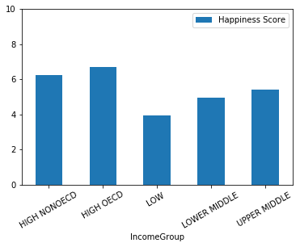

```python
merged['IncomeGroup'] = merged['IncomeGroup'].str.replace('income','').str.replace(':','').str.replace('  ',' ').str.upper()

pv_incomes = merged.pivot_table(index = 'IncomeGroup', values = 'Happiness Score') #default function is mean

pv_incomes.plot(kind = 'bar', rot = 30, ylim = (0,10)) #panda method
```

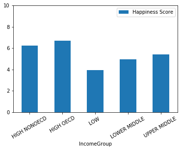

```python
merged['IncomeGroup'] = merged['IncomeGroup'].str.replace(' income', '').str.replace(':', '').str.upper()

pv_incomes = merged.pivot_table(index = 'IncomeGroup', values = 'Happiness Score') #default function is mean

pv_incomes.plot(kind = 'bar', rot = 30, ylim = (0,10)) #panda method
plt.show()
```

In this mission, we explored the benefits of using vectorized string methods, along with a couple methods that can be used to perform tasks such as finding substrings, extracting substrings, and removing substrings from columns. You can find the full list of vectorized string methods here. We encourage you to explore more string methods or string cleaning tasks independently.

In the next mission, we'll return to another important data cleaning task - how to handle missing values.